# Moringa_school_IP_Week14_Association_rule

Mutura Kuria

2/9/2022

# Business Understanding

Carrefour Kenya and are currently undertaking a project that will inform the marketing department on the most relevant marketing strategies that will result in the highest no. of sales (total price including tax). create association rules that will allow you to identify relationships between variables in the dataset. You are provided with a separate dataset that comprises groups of items that will be associated with others. Just like in the other sections, you will also be required to provide insights for your analysis.

# lnstall neccessary Libraries

```r
install.packages("arules")
library(arules)
```

```r
install.packages("arulesViz")
library(arulesViz)
```

# Load the dataset

```r
items.data= read.csv('http://bit.ly/SupermarketDatasetII')
head(items.data)
```

```
##              shrimp      almonds    avocado   vegetables.mix green.grapes
## 1           burgers    meatballs       eggs
## 2           chutney
## 3            turkey      avocado
## 4     mineral water         milk energy bar whole wheat rice    green tea
## 5    low fat yogurt
## 6 whole wheat pasta french fries
##   whole.weat.flour yams cottage.cheese energy.drink tomato.juice low.fat.yogurt
## 1
## 2
## 3
## 4
## 5
## 6
##   green.tea honey salad mineral.water salmon antioxydant.juice frozen.smoothie
## 1
## 2
## 3
## 4
## 5
## 6
##   spinach olive.oil
## 1                NA
## 2                NA
## 3                NA
## 4                NA
## 5                NA
## 6                NA
```

```r
# Data dimensions
dim(items.data)
```

```
## [1] 7500   20
```

-The dataset has 7500 transaction and atmost 20 items purchased at once

```r
#Transactions Summary
summary(items.data)
```

```
##     shrimp            almonds            avocado          vegetables.mix
##  Length:7500        Length:7500        Length:7500        Length:7500
##  Class :character   Class :character   Class :character   Class :character
##  Mode  :character   Mode  :character   Mode  :character   Mode  :character
##  green.grapes       whole.weat.flour       yams           cottage.cheese
##  Length:7500        Length:7500        Length:7500        Length:7500
##  Class :character   Class :character   Class :character   Class :character
##  Mode  :character   Mode  :character   Mode  :character   Mode  :character
##  energy.drink       tomato.juice       low.fat.yogurt      green.tea
##  Length:7500        Length:7500        Length:7500        Length:7500
##  Class :character   Class :character   Class :character   Class :character
##  Mode  :character   Mode  :character   Mode  :character   Mode  :character
##     honey              salad           mineral.water         salmon
##  Length:7500        Length:7500        Length:7500        Length:7500
##  Class :character   Class :character   Class :character   Class :character
##  Mode  :character   Mode  :character   Mode  :character   Mode  :character
##  antioxydant.juice  frozen.smoothie      spinach          olive.oil
##  Length:7500        Length:7500        Length:7500        Mode:logical
##  Class :character   Class :character   Class :character   NA's:7500
##  Mode  :character   Mode  :character   Mode  :character
```

```r
#Structure
str(items.data)
```

```
## 'data.frame':    7500 obs. of  20 variables:
##  $ shrimp           : chr  "burgers" "chutney" "turkey" "mineral water" ...
##  $ almonds          : chr  "meatballs" "" "avocado" "milk" ...
##  $ avocado          : chr  "eggs" "" "" "energy bar" ...
##  $ vegetables.mix   : chr  "" "" "" "whole wheat rice" ...
##  $ green.grapes     : chr  "" "" "" "green tea" ...
##  $ whole.weat.flour : chr  "" "" "" "" ...
##  $ yams             : chr  "" "" "" "" ...
##  $ cottage.cheese   : chr  "" "" "" "" ...
##  $ energy.drink     : chr  "" "" "" "" ...
##  $ tomato.juice     : chr  "" "" "" "" ...
##  $ low.fat.yogurt   : chr  "" "" "" "" ...
##  $ green.tea        : chr  "" "" "" "" ...
##  $ honey            : chr  "" "" "" "" ...
##  $ salad            : chr  "" "" "" "" ...
##  $ mineral.water    : chr  "" "" "" "" ...
##  $ salmon           : chr  "" "" "" "" ...
##  $ antioxydant.juice: chr  "" "" "" "" ...
##  $ frozen.smoothie  : chr  "" "" "" "" ...
##  $ spinach          : chr  "" "" "" "" ...
##  $ olive.oil        : logi  NA NA NA NA NA NA ...
```

-Only olive oil is a logical data others are characters

# Missing Values

```r
# Counting missing values
colSums(is.na(items.data))
```

```
##            shrimp           almonds           avocado    vegetables.mix
##                 0                 0                 0                 0
##      green.grapes  whole.weat.flour              yams    cottage.cheese
##                 0                 0                 0                 0
##      energy.drink      tomato.juice    low.fat.yogurt         green.tea
##                 0                 0                 0                 0
##             honey             salad     mineral.water            salmon
##                 0                 0                 0                 0
## antioxydant.juice   frozen.smoothie           spinach         olive.oil
##                 0                 0                 0              7500
```

```r
as.character(items.data$olive.oil)
```

[output not shown]

[output cut: 298 more lines]

Lets drop the logic data of olive oil

```r
items.data$olive.oil <- NULL
```

```r
colSums(is.na(items.data))
```

```
##            shrimp           almonds           avocado    vegetables.mix
##                 0                 0                 0                 0
##      green.grapes  whole.weat.flour              yams    cottage.cheese
##                 0                 0                 0                 0
##      energy.drink      tomato.juice    low.fat.yogurt         green.tea
##                 0                 0                 0                 0
##             honey             salad     mineral.water            salmon
##                 0                 0                 0                 0
## antioxydant.juice   frozen.smoothie           spinach
##                 0                 0                 0
```

# Fequencies

```r
# coerce data frame into transaction. Plotting the dataframe directly fails
trans <- as(items.data, "transactions")
#Lets find the most frequent item
summary(trans)
```

```
## transactions as itemMatrix in sparse format with
##  7500 rows (elements/itemsets/transactions) and
##  1280 columns (items) and a density of 0.01484375
##
## most frequent items:
##           spinach= antioxydant.juice=   frozen.smoothie=            salmon=
##               7498               7497               7497               7493
##     mineral.water=            (Other)
##               7476             105039
##
## element (itemset/transaction) length distribution:
## sizes
##   19
## 7500
##
##    Min. 1st Qu.  Median    Mean 3rd Qu.    Max.
##      19      19      19      19      19      19
##
## includes extended item information - examples:
##                     labels variables            levels
## 1           shrimp=almonds    shrimp           almonds
## 2 shrimp=antioxydant juice    shrimp antioxydant juice
## 3         shrimp=asparagus    shrimp         asparagus
##
## includes extended transaction information - examples:
##   transactionID
## 1             1
## 2             2
## 3             3
```

Here we see the frequency is: - Spinach =7498 - antioxydant.juice = 7497 -Frozen smoothie = 7497

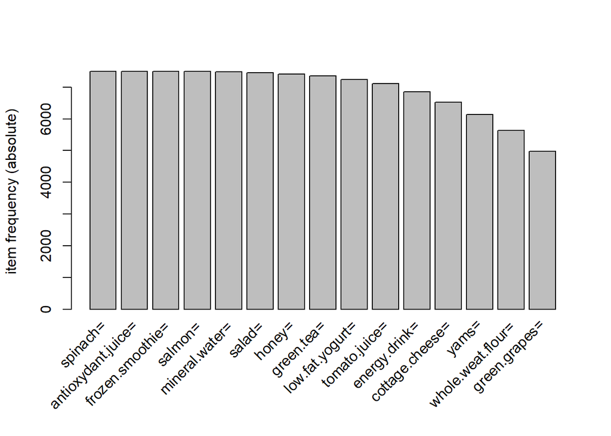

```r
# plot item frequency for first 15 items
itemFrequencyPlot(trans,topN=15,type="absolute")
```

# Association Rules

-Confidence is an indication of how often the rule has been found to be true.

-Support is an indication of how frequently the itemset appears in the dataset

```r
# Get the rules
rules <- apriori(items.data, parameter = list(supp = 0.5, conf = 0.8,target = "rules",minlen=2))
```

```
## Apriori
##
## Parameter specification:
##  confidence minval smax arem  aval originalSupport maxtime support minlen
##         0.8    0.1    1 none FALSE            TRUE       5     0.5      2
##  maxlen target  ext
##      10  rules TRUE
##
## Algorithmic control:
##  filter tree heap memopt load sort verbose
##     0.1 TRUE TRUE  FALSE TRUE    2    TRUE
##
## Absolute minimum support count: 3750
##
## set item appearances ...[0 item(s)] done [0.00s].
## set transactions ...[1280 item(s), 7500 transaction(s)] done [0.03s].
## sorting and recoding items ... [16 item(s)] done [0.00s].
## creating transaction tree ... done [0.00s].
## checking subsets of size 1 2 3 4 5 6 7 8 9 10
```

```
##  done [0.01s].
## writing ... [425218 rule(s)] done [0.11s].
## creating S4 object  ... done [0.17s].
```

```r
summary(rules)
```

```
## set of 425218 rules
##
## rule length distribution (lhs + rhs):sizes
##     2     3     4     5     6     7     8     9    10
##   204  1478  6576 20134 45002 75943 98616 99417 77848
##
##    Min. 1st Qu.  Median    Mean 3rd Qu.    Max.
##   2.000   7.000   8.000   7.986   9.000  10.000
##
## summary of quality measures:
##     support         confidence        coverage           lift
##  Min.   :0.5541   Min.   :0.8108   Min.   :0.5541   Min.   :1.000
##  1st Qu.:0.5541   1st Qu.:1.0000   1st Qu.:0.5541   1st Qu.:1.001
##  Median :0.6629   Median :1.0000   Median :0.6629   Median :1.021
##  Mean   :0.6455   Mean   :0.9882   Mean   :0.6545   Mean   :1.095
##  3rd Qu.:0.7516   3rd Qu.:1.0000   3rd Qu.:0.7516   3rd Qu.:1.150
##  Max.   :0.9996   Max.   :1.0000   Max.   :0.9997   Max.   :1.508
##      count
##  Min.   :4156
##  1st Qu.:4156
##  Median :4972
##  Mean   :4841
##  3rd Qu.:5637
##  Max.   :7497
##
## mining info:
##        data ntransactions support confidence
##  items.data          7500     0.5        0.8
```

-Model has 2109165 rules from 7500 transactions if minimum support of 0.04 is specified.

-The rules reduce to 425231 when minimum support is increased to 0.5. This is preffered to prevent persistent session crashes due to too many rules.

-when minlen=2 parameter is applied to eliminate the products whose LHS is blank, the rules are reduced to 425218

```r
inspect(rules[1:20])
```

```
##      lhs                    rhs                  support   confidence coverage
## [1]  {vegetables.mix=}   => {green.grapes=}      0.5541333 1.0000000  0.5541333
## [2]  {green.grapes=}     => {vegetables.mix=}    0.5541333 0.8358809  0.6629333
## [3]  {vegetables.mix=}   => {whole.weat.flour=}  0.5541333 1.0000000  0.5541333
## [4]  {vegetables.mix=}   => {yams=}              0.5541333 1.0000000  0.5541333
## [5]  {vegetables.mix=}   => {cottage.cheese=}    0.5541333 1.0000000  0.5541333
## [6]  {vegetables.mix=}   => {energy.drink=}      0.5541333 1.0000000  0.5541333
## [7]  {vegetables.mix=}   => {tomato.juice=}      0.5541333 1.0000000  0.5541333
## [8]  {vegetables.mix=}   => {low.fat.yogurt=}    0.5541333 1.0000000  0.5541333
## [9]  {vegetables.mix=}   => {green.tea=}         0.5541333 1.0000000  0.5541333
## [10] {vegetables.mix=}   => {honey=}             0.5541333 1.0000000  0.5541333
## [11] {vegetables.mix=}   => {salad=}             0.5541333 1.0000000  0.5541333
## [12] {vegetables.mix=}   => {mineral.water=}     0.5541333 1.0000000  0.5541333
## [13] {vegetables.mix=}   => {salmon=}            0.5541333 1.0000000  0.5541333
## [14] {vegetables.mix=}   => {antioxydant.juice=} 0.5541333 1.0000000  0.5541333
```

[output cut: 27 more lines]

If someone buys vegetables.mix, they are 100% likely to buy green.grapes too.

If someon buys yams, they are 81% likely to buy green.grapes.